# Chapter 7: Exploratory Data Analysis

Arnold Taremwa

1 June 2017

# Exploratory Data Analysis

## Prerequisites

```r
library(tidyverse)
library(ggstance)
```

```r
library(lvplot)
library(ggbeeswarm)
library(hexbin)
```

## 7.3.1 Visualizing distribution

Categorical variable

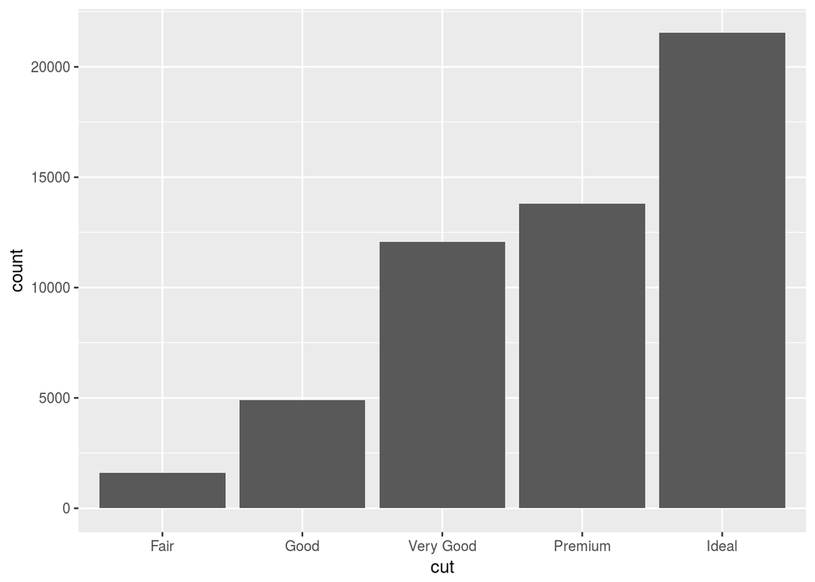

```r
ggplot(data = diamonds) +
  geom_bar(mapping = aes(x = cut))
```

```r
diamonds %>%
  count(cut)
```

```
## # A tibble: 5 × 2
##         cut     n
##       <ord> <int>
## 1      Fair  1610
## 2      Good  4906
## 3 Very Good 12082
## 4   Premium 13791
## 5     Ideal 21551
```

Continuous variable

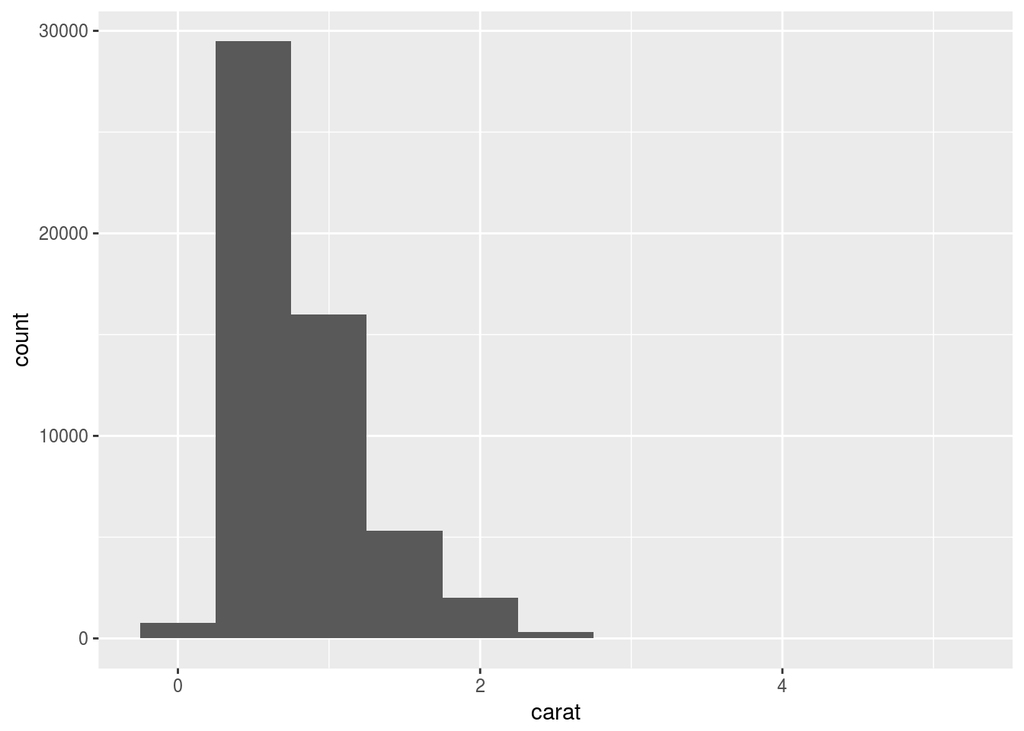

```r
ggplot(data = diamonds) +
  geom_histogram(mapping = aes(x = carat), binwidth = 0.5)
```

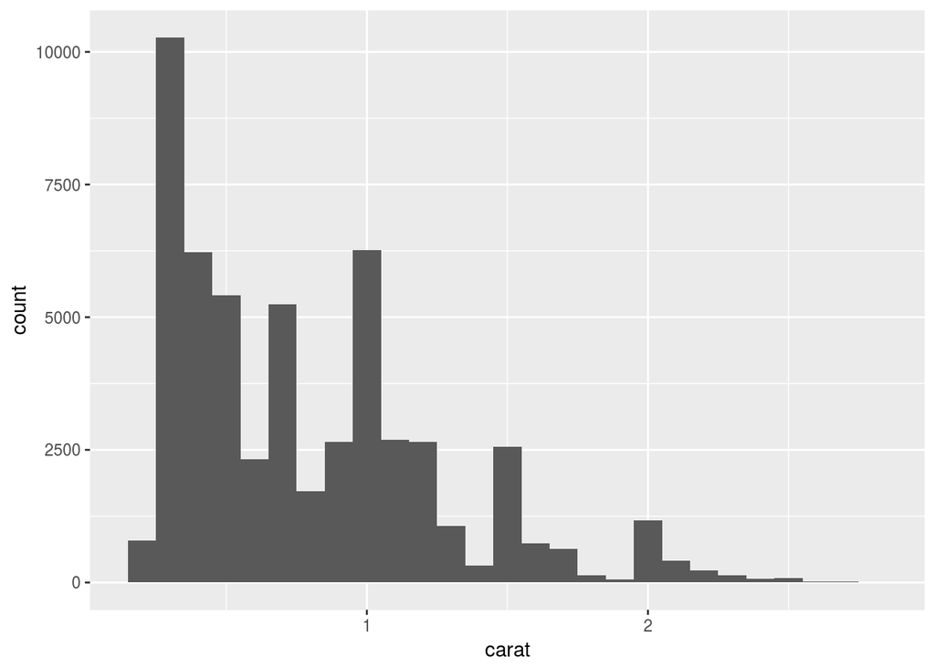

```r
diamonds %>%
  filter(carat < 3) %>%
  ggplot() +
    geom_histogram(mapping = aes(x = carat), binwidth = 0.1)
```

Grouping

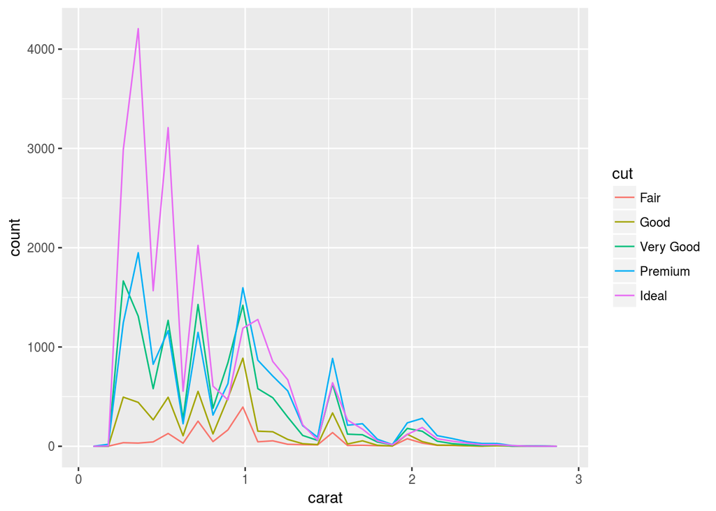

```r
diamonds %>%
  filter(carat < 3) %>%
  ggplot() +
    geom_freqpoly(mapping = aes(x = carat, colour = cut))
```

Unusual values

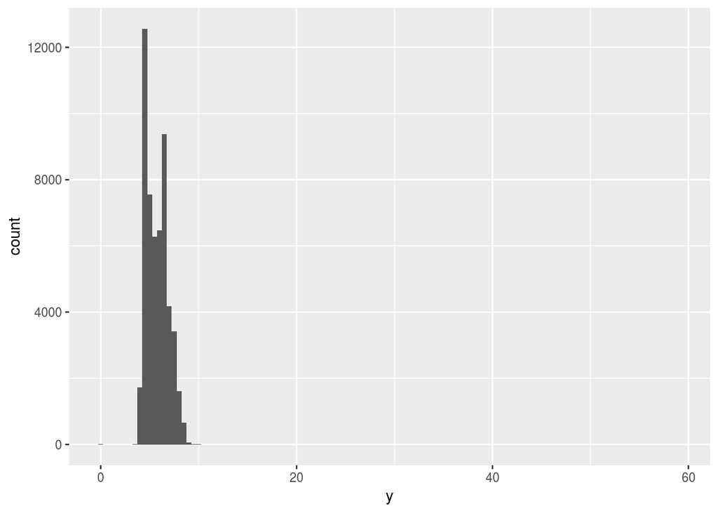

```r
ggplot(data = diamonds) +
  geom_histogram(mapping = aes(x = y), binwidth = 0.5)
```

Zoom in

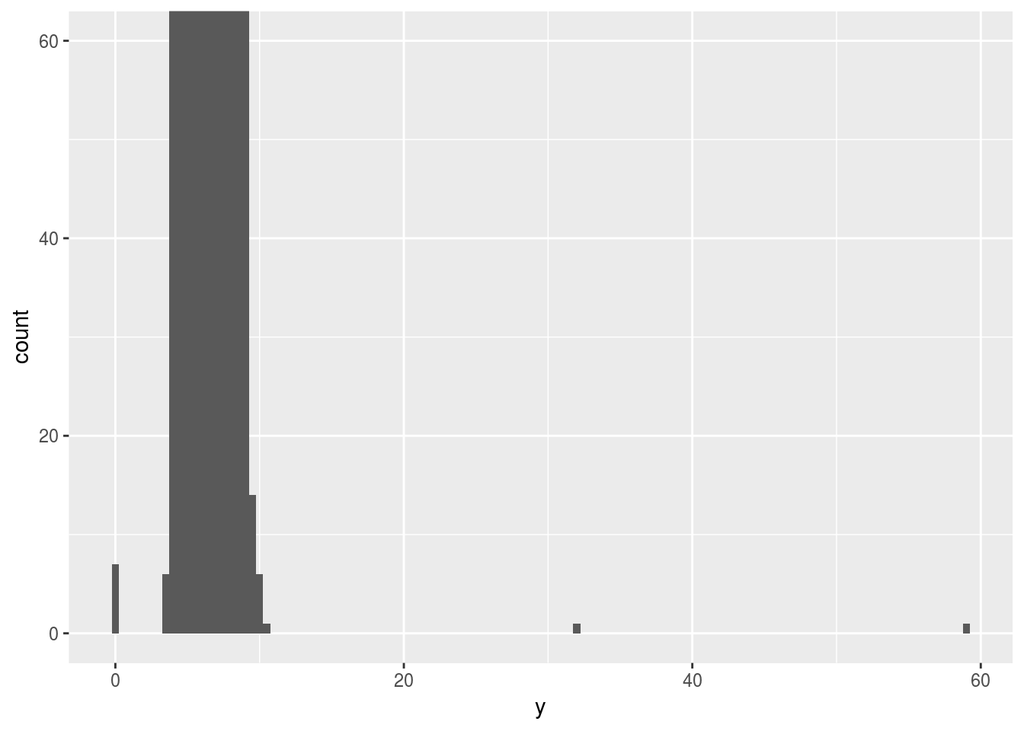

```r
ggplot(data = diamonds) +
  geom_histogram(mapping = aes(x = y), binwidth = 0.5) +
  coord_cartesian(ylim = c(0, 60))
```

```r
diamonds %>%
  filter(y < 3 | y > 20) %>%
  select(x, y, z) %>%
  arrange(y)
```

```
## # A tibble: 9 × 3
##       x     y     z
##   <dbl> <dbl> <dbl>
## 1  0.00   0.0  0.00
## 2  0.00   0.0  0.00
## 3  0.00   0.0  0.00
## 4  0.00   0.0  0.00
## 5  0.00   0.0  0.00
## 6  0.00   0.0  0.00
## 7  0.00   0.0  0.00
## 8  5.15  31.8  5.12
## 9  8.09  58.9  8.06
```

## 7.3.4 Exercises

1. Explore the distribution of each of the x, y, and z variables in diamonds. What do you learn? Think about a diamond and how you might decide which dimension is the length, width, and depth.

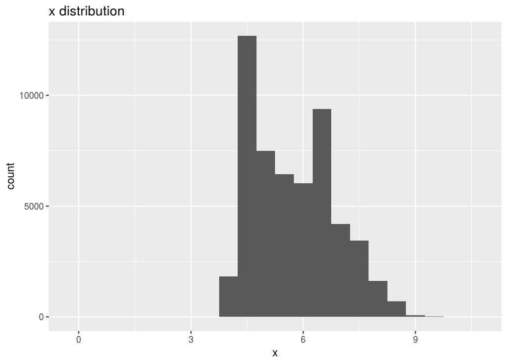

```r
ggplot(diamonds) +
  geom_histogram(aes(x), binwidth = 0.5) +
  labs(title = "x distribution")
```

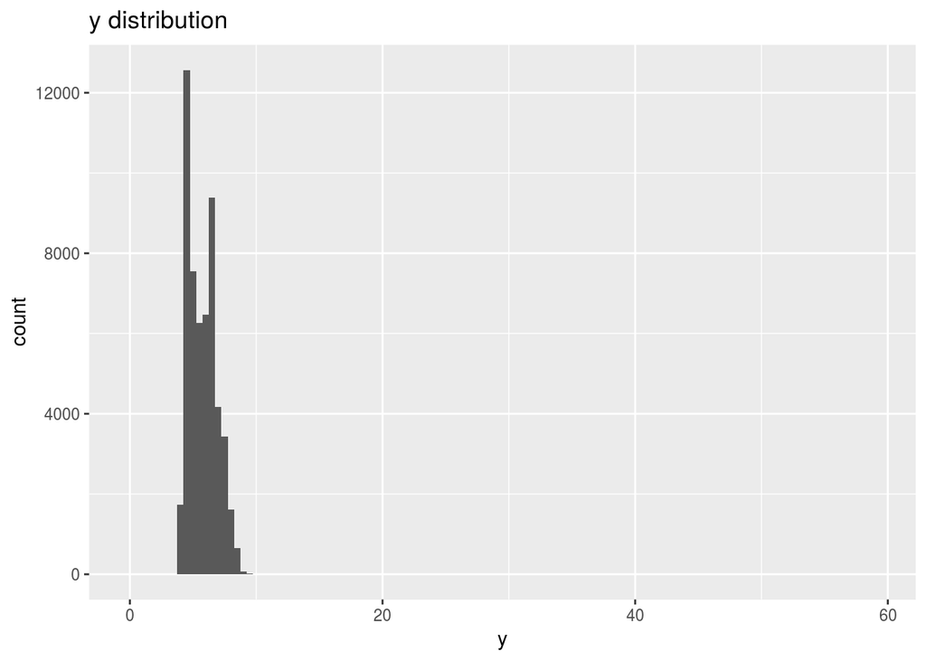

```r
ggplot(diamonds) +
  geom_histogram(aes(y), binwidth = 0.5) +
  labs(title = "y distribution")
```

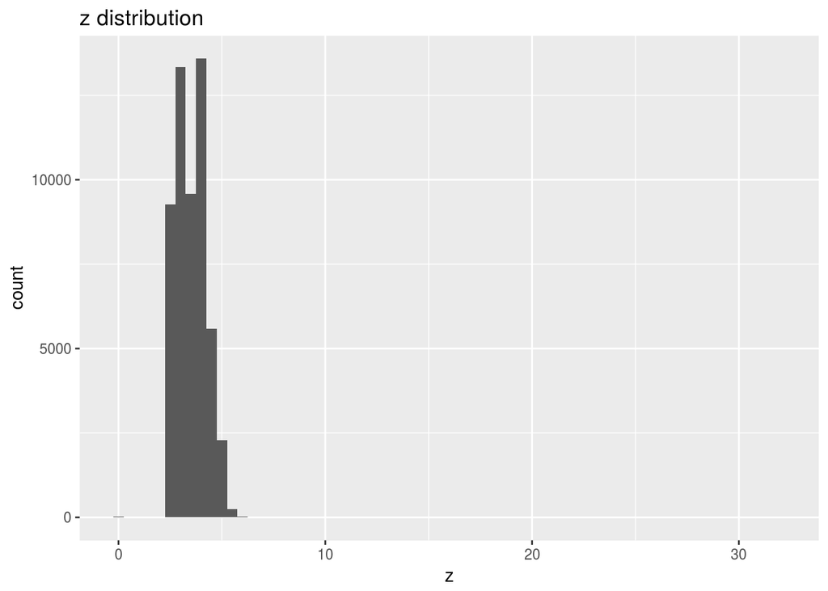

```r
ggplot(diamonds) +
  geom_histogram(aes(z), binwidth = 0.5) +
  labs(title = "z distribution")
```

2. Explore the distribution of price. Do you discover anything unusual or surprising? (Hint: Carefully think about the binwidth and make sure you try a wide range of values.)

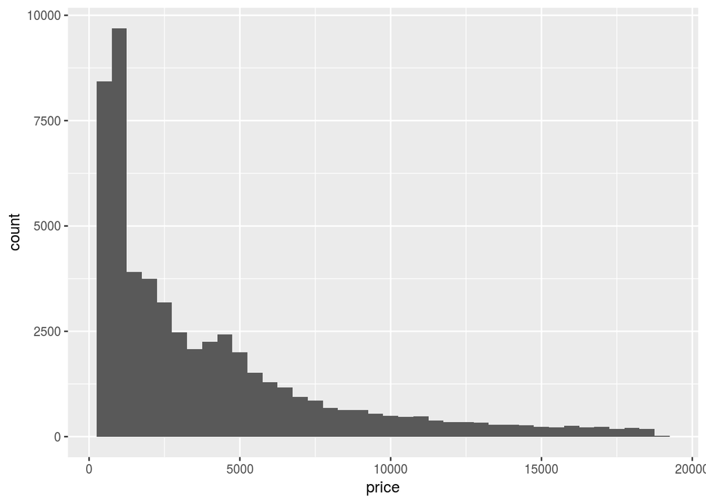

```r
ggplot(diamonds) +
  geom_histogram(aes(price), binwidth = 500)
```

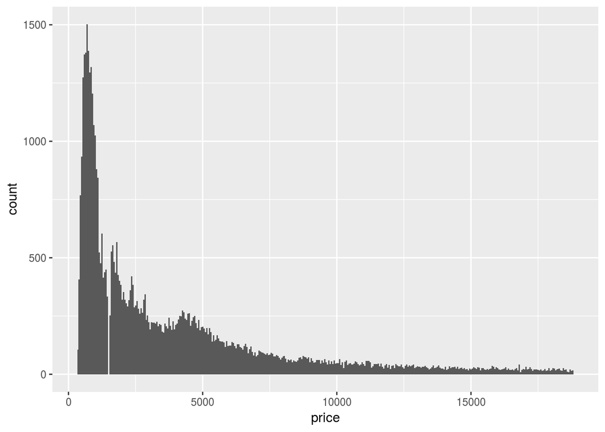

```r
ggplot(diamonds) +
  geom_histogram(aes(price), binwidth = 50)
```

```r
diamonds %>%
  count(cut_width(price, 50)) %>%
  filter(n <= 10)
```

```
## # A tibble: 2 × 2
##   `cut_width(price, 50)`     n
##                   <fctr> <int>
## 1  (1.682e+04,1.688e+04]     9
## 2  (1.862e+04,1.868e+04]     9
```

3. How many diamonds are 0.99 carat? How many are 1 carat? What do you think is the cause of the difference?

```r
diamonds %>%
  summarise(
    n_0_99 = sum(carat == 0.99),
    n_1 = sum(carat == 1)
  )
```

```
## # A tibble: 1 × 2
##   n_0_99   n_1
##    <int> <int>
## 1     23  1558
```

4. Compare and contrast coord_cartesian() vs xlim() or ylim() when zooming in on a histogram. What happens if you leave binwidth unset? What happens if you try and zoom so only half a bar shows?

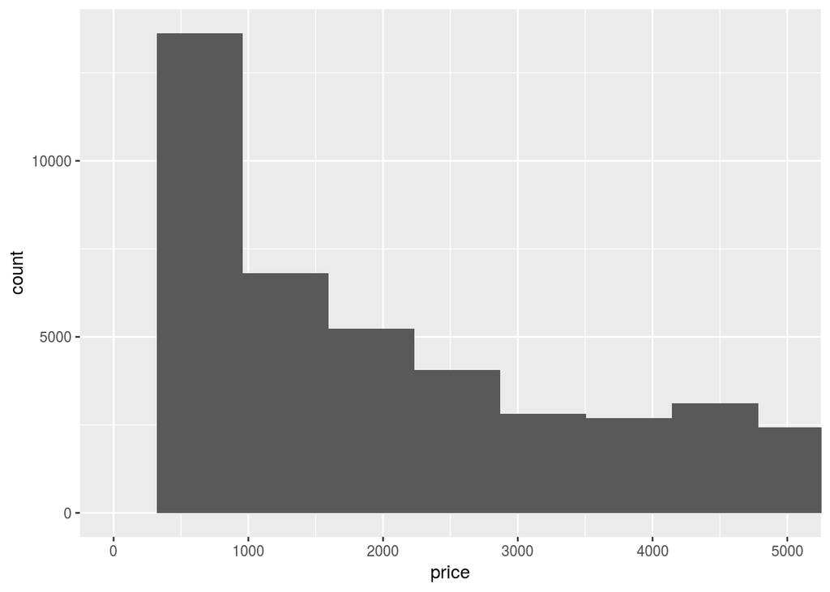

```r
ggplot(diamonds) +
  geom_histogram(aes(price)) +
  coord_cartesian(xlim = c(0, 5000))
```

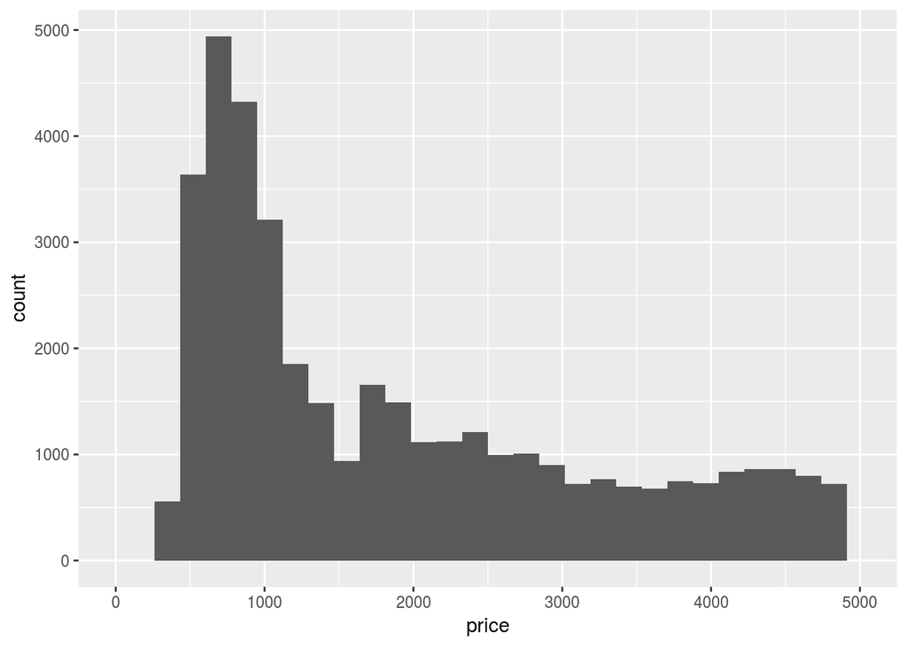

```r
ggplot(diamonds) +
  geom_histogram(aes(price)) +
  xlim(0, 5000)
```